# Assessment of Excess Mortality and Household Income in Rural Bangladesh During the COVID-19 Pandemic in 2020

Hancheng Li

2024-02-23

# Assessment of Excess Mortality and Household Income in Rural Bangladesh During the COVID-19 Pandemic in 2020

To quantify the association of the COVID-19 pandemic with excess mortality and household income in rural Bangladesh in 2020.

```r
#Specify data
#Four dimensions are: age(every 10 years old as a group, 9 groups in total), gender(male,female), education level(2), month(2019.1-2020.1)


data {
  int<lower=0> N_age;                 #number of age
  int<lower=0> N_month;               #number of month
  int cases[N_age,2,2,N_month];       #number of cases for each group
  int exposures[N_age,2,2,N_month];   #number of exposures for each group
  int covid_start;                    #covid start indicator
}


parameters {
  real age_eff[N_age];                #age group effect
  real month_eff[11];                 #monthly effect for firsr 11 months
  real edu_eff;                       #edu effect
  real gender_eff;                    #gender effect
  real covid_eff[N_age];              #covid effect to each age group
  real covid_male;                    #covid effect to male
  real covid_edu;                     #covid effect to edu
  real<lower=0> sigma_age;            #sd for priors age
  real<lower=0> sigma_age2;           #              covide age
  real<lower=0> sigma_month;          #              monthly effect
}

transformed parameters {
  real time_eff[N_month];             #repreating month effect over study period
  real rate[N_age,2,2,N_month];       #rate of cases for each combinantion of each group
  time_eff[1]=0;                      #first month is 0
  time_eff[2:12]=month_eff;           #second to 12th is same as month effect
  time_eff[(12+1):N_month]=time_eff[1:(N_month-12)];
  for(i1 in 1:N_age)                  #13th to 22nd is same as that of 1st to 10th
    for(i2 in 1:2)
        for(i3 in 1:2)
          for(i4 in 1:N_month){
              rate[i1, i2, i3, i4] = age_eff[i1]+time_eff[i4];
              if(i2==2)
              rate[i1, i2, i3, i4] += gender_eff;
               if(i3==2)
              rate[i1, i2, i3, i4] += edu_eff;
              if(i4>=12+covid_start){
              rate[i1, i2, i3, i4] += covid_eff[i1];
               if(i2==2)
              rate[i1, i2, i3, i4] += covid_male;
               if(i3==2)
              rate[i1, i2, i3, i4] += covid_edu;
              }
          }

}
```

$$y_j \sim Binomial(n_j,\theta_j),where j=(j_1,j_2,j_3,j_4)$$
$$j_i=1,...,22;j_2=1,...,9;j_3=1(female),2(male);j_4=1(low),2(high)$$

Logistic Model:

Baseline mortality rate(pre covid)
$$logit(\theta_j) = a_{j_1mod12}+a_{j_2}+a_{j_3}+a_{j_4}$$

Post-Covid mortality rate:

$$logit(\theta_j)=a_{j_1
mod12}+age_{j_2}+gender.eff_{j_3}+edu.eff_{j_4}+covid.eff_{j_2}+covid.male_{j_3}+covid.edu_{j_4}$$

# Priors:

Partial pooling priors are adopted to this model via lag-1 AR structrue for parameteres that depend on time:

Age effect:

$a_1 \sim N(-8,4)$ weakly informative prior, $a_{j_1} \sim N(a_{j_1-1},\sigma^2_{age})$ for $1<j_1<9$;

Age+Covid effect:

$age.c_{j_1} \sim N(age.c_{j_1-1},\sigma^2_{age.c})$ for $1<j_1\leq9$\

Month effect:

$a_{j_1} \sim N(a_{j_1-1},\sigma^2_m)$ for $2\leq j_1\leq11$,

- The gender effect ($\text{gender_eff}$) is assumed to follow a standard normal distribution:

  $$\text{gender_eff} \sim N(0,
  1)$$
- The COVID effect for each age group ($\text{covid_eff}$) follows a standard normal distribution:

  $$\text{covid_eff} \sim N(0,
  1)$$
- The standard deviation for monthly effects ($\sigma_{\text{month}}$) follows a standard normal distribution:

  $$\sigma_{\text{month}} \sim N(0,
  1)$$
- The standard deviation for age effects ($\sigma_{\text{age}}$) follows a standard normal distribution:

  $$\sigma_{\text{age}} \sim N(0,
  1)$$
- The standard deviation for COVID age effects ($\sigma_{\text{age2}}$) follows a standard normal distribution:

  $$\sigma_{\text{age2}} \sim N(0,
  1)$$
- The additional COVID effect for males ($\text{covid_male}$) follows a standard normal distribution:

  $$\text{covid_male} \sim N(0,
  1)$$
- The education effect ($\text{edu_eff}$) is assumed to follow a normal distribution with mean 0 and standard deviation 0.5:

  $$\text{edu_eff} \sim N(0,
  0.5)$$
- The additional COVID effect for those with higher education ($\text{covid_edu}$) follows a normal distribution with mean 0 and standard deviation 0.5:

  $$\text{covid_edu} \sim N(0,
  0.5)$$

```r
model {
  for(i1 in 1:N_age)
    for(i2 in 1:2)
        for(i3 in 1:2)
          for(i4 in 1:N_month)
              cases[i1, i2, i3, i4]~ binomial_logit(exposures[i1, i2, i3, i4],  rate[i1, i2, i3, i4] ); #likelihood
   for(i in 2:N_age)
      target+= -0.5*(  age_eff[i]-age_eff[i-1])^2/sigma_age^2; #  lag-1 AR prior             prior for age effect
   age_eff[1]~normal(-8,4); #weakly informative prior for the first one
   for(i in 2:N_age)
      target+= -0.5*(covid_eff[i]-covid_eff[i-1])^2/sigma_age2^2;  #prior for age after covid effect
   for(i in 2:11)
      target+= -0.5*(month_eff[i]-month_eff[i-1])^2/sigma_month^2; #prior for month effect
   target+= -(0-month_eff[11])^2/sigma_month^2;
   gender_eff~std_normal();
   covid_eff~std_normal();
   sigma_month~std_normal();
   sigma_age~std_normal();
   sigma_age2~std_normal();
   covid_male~std_normal();
   edu_eff~normal(0,0.5);
   covid_edu~normal(0,0.5);
}
```

fitted Baseline mortality based on MCMC posterior samples of above parameters:

$$\hat{\theta}_{j_2,j_3,j_4}=logit^{-1}(age.eff_{j_2}+gender.eff_{j_3}+edu.eff_{j_4}+\frac{1}{12}\sum_{j_1=1}^{12}month.eff_{j_1})$$

fitted post covid mortality:

$$\hat{\theta}^*_{j_2,j_3,j_4}=logit^{-1}(age.eff_{j_2}+gender.eff_{j_3}+edu.eff_{j_4}\\
+covidage.eff_{j_2}+covid.male.eff_{j_3}+covid.edu.eff_{j_4}+\frac{1}{12}\sum_{j_1=1}^{12}month.eff_{j_1})$$

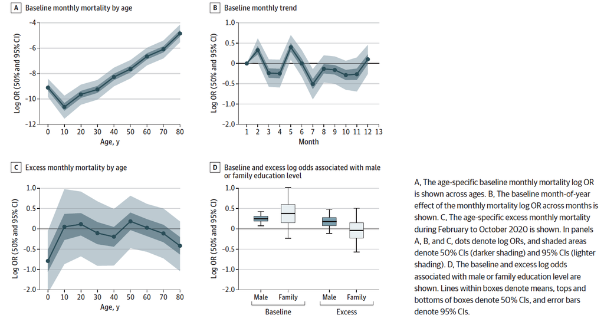

```r
knitr::include_graphics("mortality.1.png")
```

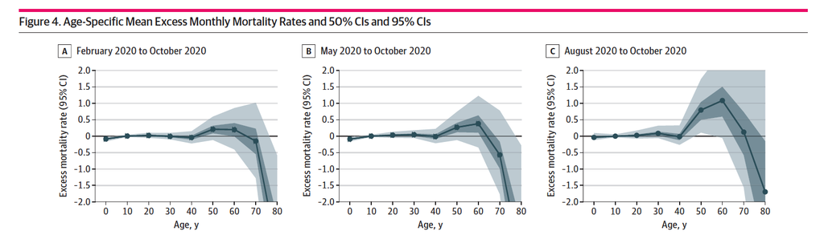

```r
knitr::include_graphics("mortality.2.png")
```